# Data Open Lecture: An Introduction of Python

## Scikit-learn (2.2): Single Model Training

```python
# Train a linear model in scikit-learn
import sklearn.linear_model as lm
model_lm = lm.LinearRegression()
model_lm.fit(Xt, Yt)
```

```
LinearRegression(copy_X=True, fit_intercept=True, n_jobs=1, normalize=False)
```

```python
# Coefficients of the model
model_lm.coef_
```

```
array([ 11641.894,    -66.581,    -25.287,  -1140.763,    -12.209,
          -63.557,    551.371,    841.153,    754.372,    708.06 ,
         -177.767,   -244.366,   -447.098,   -956.701,  -1445.476,
        -2299.875,   5297.921,   3686.544,   2714.422,   4585.986,
         4267.393,   4996.976,   4937.163])
```

```python
# Prediction on traing-validation set
Ythat = model_lm.predict(Xt)
Yvhat = model_lm.predict(Xv)
Yvhat
```

```
array([ 4134.981,  2131.571,  6300.447, ...,  1760.954,   277.292,
         934.741])
```

```python
# Measure the training-validation loss
met.mean_squared_error(Yt.values, Ythat), met.mean_squared_error(Yv.values, Yvhat)
```

```
(1222405.0419276247, 1351848.6373490358)
```

## Scikit-learn (2.3): Cross-Validation Training

```python
def cv_train(X, Y, ir_cv, fmodel, fscore = met.mean_squared_error, **kwargs):
    modelL, losstL, lossvL = [], [], []
    for ir_v in ir_cv:
        # Create training-validation sets
        ir_t = np.setdiff1d(np.hstack(ir_cv), ir_v)
        Xt, Xv, Yt, Yv = X.loc[ir_t], X.loc[ir_v], Y.loc[ir_t], Y.loc[ir_v]
        # Train a scikit-learn model
        model = fmodel(**kwargs)
        model.fit(Xt, Yt)
        # predict and get training-validation loss
        Ythat = model.predict(Xt)
        losst = fscore(Yt.values, Ythat)
        Yvhat = model.predict(Xv)
        lossv = fscore(Yv.values, Yvhat)
        # save model and training-validation loss
        modelL.append(model)
        losstL.append(losst)
        lossvL.append(lossv)
    op = {"modelL": modelL,
          "loss": pd.DataFrame({"loss_train": losstL, "loss_val": lossvL})}
    return(op)

# Train linear regression CV models with MSE loss
md_lm = cv_train(X, Y, ir_cv, lm.LinearRegression)
md_lm["loss"].mean()
```

```
loss_train    1.247e+06
loss_val      1.263e+06
dtype: float64
```

## Scikit-learn (2.4): Cross-Validation Prediction

```python
# Prepare the prediction dataset
Yp = da_true.loc[ir_unlab, "price"]
Xp = X.loc[ir_unlab]
Yp.shape, Xp.shape
```

```
((14232,), (14232, 23))
```

```python
def cv_pred(X, Y, modelL, fscore = met.mean_squared_error):
    # Predict Yhat for each CV model
    YhatL = [model.predict(X) for model in modelL]
    # Get prediction loss for each Yhat
    lossL = [fscore(Yp.values, Yhat) for Yhat in YhatL]
    op = {"YhatL": YhatL, "lossL": lossL}
    return(op)

# Calculate prediction loss for each model on prediction data (Xp, Yp)
op_pred = cv_pred(Xp, Yp, md_lm["modelL"])
op_pred["lossL"], np.mean(op_pred["lossL"])
```

```
([1362963.7291103753,
  1361001.7484534772,
  1365815.447840391,
  1358742.7597344865,
  1363723.8601751626],
 1362449.5090627784)
```

```python
# Calculate the loss of mean CV prediction
met.mean_squared_error(Yp.values, np.mean(op_pred["YhatL"], axis = 0))
```

```
1360221.642421219
```

## Scikit-learn (3.1): Over-Fitting

- To train a machine learning model, when we only $\min_{\theta\in\Theta_f}L(Y, \hat{Y})$:
- An extremely complex model may always be "better" in training set (over-fitting)
  - Fit 10,000-order polynomials on $Y$ of sample-size 10,000
  - A too complex model may not be true for population out of sample
  - A too complex model may be unstable

```python
Xpoly2 = pd.concat([X, X**2], axis = 1)
Xpoly5 = pd.concat([X**(1+i) for i in range(5)], axis = 1)
X.shape, Xpoly2.shape, Xpoly5.shape
```

```
((53940, 23), (53940, 46), (53940, 115))
```

```python
pd.concat([cv_train(i, Y, ir_cv, lm.LinearRegression)['loss'].mean()
     for i in [X, Xpoly2, Xpoly5]], axis = 1, keys = ["X", "Xpoly2", "Xpoly5"])
```

|  | X | Xpoly2 | Xpoly5 |
| --- | --- | --- | --- |
| loss_train | 1.247e+06 | 1.172e+06 | 1.037e+06 |
| loss_val | 1.263e+06 | 3.141e+08 | 3.119e+13 |

## Scikit-learn (3.2): Penalty Function

- Method: find a simpler model $\hat{\theta}$ by $\min_{\theta\in\Theta_f}\left[L(Y, \hat{Y}) + \lambda P(\theta)\right]$
  - Loss function $L(Y, \hat{Y})$: control the errors of fitting
  - Penalty function $P(\theta)$: measure the complexity of model
    - Ridge (L2 dist): $P(\beta) = \sum_{i=1}^p\beta_i^2$
    - Lasso (L1 dist): $P(\beta) = \sum_{i=1}^p|\beta_i|$
    - AIC/BIC (L0 dist): $P(\beta) = \sum_{i=1}^p1(\beta_i\neq 0)$
  - Penalty coefficient $\lambda$: greater $\lambda \rightarrow$ simpler model

```python
pd.concat(
    [cv_train(i, Y, ir_cv, lm.Ridge, alpha = 0.1, normalize = True)['loss'].mean()
     for i in [X, Xpoly2, Xpoly5]], axis = 1, keys = ["X", "Xpoly2", "Xpoly5"])
```

|  | X | Xpoly2 | Xpoly5 |
| --- | --- | --- | --- |
| loss_train | 1.923e+06 | 1.538e+06 | 1.277e+06 |
| loss_val | 1.944e+06 | 2.267e+06 | 4.666e+10 |

```python
pd.concat(
    [cv_train(i, Y, ir_cv, lm.Lasso, alpha = 0.1, normalize = True)['loss'].mean()
     for i in [X, Xpoly2, Xpoly5]], axis = 1, keys = ["X", "Xpoly2", "Xpoly5"])
```

|  | X | Xpoly2 | Xpoly5 |
| --- | --- | --- | --- |
| loss_train | 1.396e+06 | 1.411e+06 | 1.251e+06 |
| loss_val | 1.400e+06 | 1.417e+06 | 3.316e+11 |

## Scikit-learn (3.3): Select Penalty Coefficients

- How to select best penalty coeffient $\hat{\lambda}$, or more generally, best hyperparameters of model?
  - Step 1. Try different $\lambda$ on the model
    - Method 1: Build several models with different $\lambda$
    - Method 2: If exists, a stepwise model for $\lambda$ can save computation time
  - Step 2. Calculate CV validation loss, and select the $\hat{\lambda}$ minimizing it
  - Step 3. If used for variable selection, choose important variables under $\hat{\lambda}$

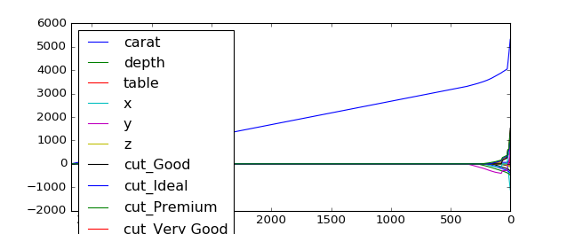

```python
path_lasso = lm.lasso_path((Xt - Xt.mean())/Xt.std(), Yt)
pd.DataFrame(path_lasso[1].T, index = path_lasso[0], columns = X.columns).plot()
```

## Scikit-learn(4.1): Decision Tree Models

- Can we detect non-linear relationship without adding polynomial terms?
- Non-linear models: e.g. tree-based methods $\hat{Y} = Tree(X, \theta)$

```python
import sklearn.tree as tree
md_tree = cv_train(X, Y, ir_cv, tree.DecisionTreeRegressor)
md_tree["loss"].mean()
```

```
loss_train        26.107
loss_val      743744.096
dtype: float64
```

```python
# The distribution of variable used as tree split
wL_tree = [model.feature_importances_ for model in md_tree["modelL"]]
pd.DataFrame(wL_tree, columns = X.columns).mean().sort_values()
```

```
cut_Very Good    2.735e-04
cut_Good         4.159e-04
                   ...
y                2.598e-01
carat            6.303e-01
dtype: float64
```

```python
# Limit the depth of tree to control model complexity
cv_train(X, Y, ir_cv, tree.DecisionTreeRegressor, max_depth = 15)["loss"].mean()
```

```
loss_train    166954.960
loss_val      669473.576
dtype: float64
```

## Scikit-learn(4.2): Random Forest

- Build $M$ trees at the same time in each model
- To increase diversity of trees, when building each tree $\hat{\theta}_i$:
  - Randomly bootstrap $(X, Y)$ to $(X_{(i)}, Y_{(i)})$
  - Randomly select a subset of variables $\Theta_{i}$
- $\hat{\theta}_i = \arg\min_{\theta_i \in \Theta_{i}}L\left(Y_{(i)}, Tree(X_{(i)}, \theta_i)\right)$
- $\hat{Y} = \frac{1}{M}\sum_{i=1}^M Tree(X, \hat{\theta}_i)$

```python
import sklearn.ensemble as ensm
md_rf = cv_train(X, Y, ir_cv, ensm.RandomForestRegressor, n_estimators=10)
md_rf["loss"].mean()
```

```
loss_train     84272.896
loss_val      452528.303
dtype: float64
```

```python
wL_rf = [model.feature_importances_ for model in md_rf["modelL"]]
pd.DataFrame(wL_rf, columns = X.columns).mean().sort_values()
```

```
cut_Very Good    3.324e-04
cut_Good         4.420e-04
                   ...
carat            4.139e-01
y                4.714e-01
dtype: float64
```

```python
np.mean(cv_pred(Xp, Yp, md_rf["modelL"])['lossL'])
```

```
482715.59347832418
```

## Scikit-learn(4.3): Gradient Boosting Trees

- Build $M$ trees stepwisely for residuals in each model
- To reduce over-fitting, when building each tree $\hat{\theta}_i$:
  - Restrict max depth of tree
  - Restrict step size $\eta < 1$
- $\hat{\theta}_i = \arg\min_{\theta_i \in \Theta}L\left(Y - \eta\sum_{j=1}^{i-1}Tree(X, \theta_j), Tree(X, \theta_i)\right)$
- $\hat{Y} = \eta\sum_{i=1}^M Tree(X, \hat{\theta}_i)$

```python
md_gbt = cv_train(X, Y, ir_cv, ensm.GradientBoostingRegressor, n_estimators = 300, learning_rate = 0.3)
md_gbt["loss"].mean()
```

```
loss_train    294816.887
loss_val      414659.551
dtype: float64
```

```python
wL_gbt = [model.feature_importances_ for model in md_gbt["modelL"]]
pd.DataFrame(wL_gbt, columns = X.columns).mean().sort_values()
```

```
cut_Very Good    0.001
cut_Good         0.002
                 ...
carat            0.131
y                0.180
dtype: float64
```

```python
np.mean(cv_pred(Xp, Yp, md_gbt["modelL"])['lossL'])
```

```
444176.13327725837
```

```python
'''
He Was Pierced for Our Transgressions


    But he was pierced for our transgressions;

        he was crushed for our iniquities;

    upon him was the chastisement that brought us peace,

        and with his wounds we are healed.

    All we like sheep have gone astray;

        we have turned—every one—to his own way;

    and the LORD has laid on him

        the iniquity of us all.



(Isaiah 53:5-6 ESV)
'''
```

# Review: Data Analysis for Titanic

## Preparation

- Bring your laptop
- Download and Install [Anaconda](https://www.continuum.io/downloads) (Python 3.5 version)
- Download file "Titanic.csv" from [lecture repository](https://github.com/founderfan/Data-Open-Lecture)
- Open Jupyter Notebook
- Open saved notebook last time
  - or create a new notebook: Right-upper area $\rightarrow$ New $\rightarrow$ Notebooks $\rightarrow$ Python
- Be ready to type in code!

## Contents

1. Load and Format Data
   - Rename
   - Index and Reindex
   - String Operations in Series
2. Summary Tables
3. Bivariate Association
4. Data Cleaning
5. Machine Learning: Classification
   - ROC and AUC
   - Logistic Regression
   - Tree-based Methods
   - Variable Selection

## Review (1.1): Load Data

```python
# Load modules and set options
import numpy as np
import pandas as pd
import matplotlib.pyplot as plt

np.set_printoptions(precision = 3)
pd.set_option('precision', 3)
%matplotlib notebook
%cd ~/Stat
```

```
/Users/fangda/Stat
```

```python
# Load data
da = pd.read_csv("Titanic.csv")
da.shape
```

```
(891, 12)
```

```python
da.head()
```

|  | PassengerId | Survived | Pclass | Name | Sex | Age | SibSp | Parch | Ticket | Fare | Cabin | Embarked |
| --- | --- | --- | --- | --- | --- | --- | --- | --- | --- | --- | --- | --- |
| 0 | 1 | 0 | 3 | Braund, Mr.... | male | 22.0 | 1 | 0 | A/5 21171 | 7.250 | NaN | S |
| 1 | 2 | 1 | 1 | Cumings, Mr... | female | 38.0 | 1 | 0 | PC 17599 | 71.283 | C85 | C |
| 2 | 3 | 1 | 3 | Heikkinen, ... | female | 26.0 | 0 | 0 | STON/O2. 31... | 7.925 | NaN | S |
| 3 | 4 | 1 | 1 | Futrelle, M... | female | 35.0 | 1 | 0 | 113803 | 53.100 | C123 | S |
| 4 | 5 | 0 | 3 | Allen, Mr. ... | male | 35.0 | 0 | 0 | 373450 | 8.050 | NaN | S |

## Review (1.2): Format Data: Rename

```python
# DT.rename(index, columns): use a dict or lambda function to change row/column names
da.rename(columns = {"PassengerId": "Id"}).head(2)
```

|  | Id | Survived | Pclass | Name | Sex | Age | SibSp | Parch | Ticket | Fare | Cabin | Embarked |
| --- | --- | --- | --- | --- | --- | --- | --- | --- | --- | --- | --- | --- |
| 0 | 1 | 0 | 3 | Braund, Mr.... | male | 22.0 | 1 | 0 | A/5 21171 | 7.250 | NaN | S |
| 1 | 2 | 1 | 1 | Cumings, Mr... | female | 38.0 | 1 | 0 | PC 17599 | 71.283 | C85 | C |

```python
da.rename(index = lambda x: x+10000).head(2)
```

|  | PassengerId | Survived | Pclass | Name | Sex | Age | SibSp | Parch | Ticket | Fare | Cabin | Embarked |
| --- | --- | --- | --- | --- | --- | --- | --- | --- | --- | --- | --- | --- |
| 10000 | 1 | 0 | 3 | Braund, Mr.... | male | 22.0 | 1 | 0 | A/5 21171 | 7.250 | NaN | S |
| 10001 | 2 | 1 | 1 | Cumings, Mr... | female | 38.0 | 1 | 0 | PC 17599 | 71.283 | C85 | C |

```python
# DT.replace(to_replace, value): replace values in data
da.replace({"Sex": {"male": 1, "female": 0}}).head(2)
```

|  | PassengerId | Survived | Pclass | Name | Sex | Age | SibSp | Parch | Ticket | Fare | Cabin | Embarked |
| --- | --- | --- | --- | --- | --- | --- | --- | --- | --- | --- | --- | --- |
| 0 | 1 | 0 | 3 | Braund, Mr.... | 1 | 22.0 | 1 | 0 | A/5 21171 | 7.250 | NaN | S |
| 1 | 2 | 1 | 1 | Cumings, Mr... | 0 | 38.0 | 1 | 0 | PC 17599 | 71.283 | C85 | C |

## Review (1.3): Format Data: Set and Reset Index

```python
da = da.set_index("PassengerId")
da.head(2)
```

| PassengerId | Survived | Pclass | Name | Sex | Age | SibSp | Parch | Ticket | Fare | Cabin | Embarked |
| --- | --- | --- | --- | --- | --- | --- | --- | --- | --- | --- | --- |
| 1 | 0 | 3 | Braund, Mr.... | male | 22.0 | 1 | 0 | A/5 21171 | 7.250 | NaN | S |
| 2 | 1 | 1 | Cumings, Mr... | female | 38.0 | 1 | 0 | PC 17599 | 71.283 | C85 | C |

```python
da.reset_index().head(2)
```

|  | PassengerId | Survived | Pclass | Name | Sex | Age | SibSp | Parch | Ticket | Fare | Cabin | Embarked |
| --- | --- | --- | --- | --- | --- | --- | --- | --- | --- | --- | --- | --- |
| 0 | 1 | 0 | 3 | Braund, Mr.... | male | 22.0 | 1 | 0 | A/5 21171 | 7.250 | NaN | S |
| 1 | 2 | 1 | 1 | Cumings, Mr... | female | 38.0 | 1 | 0 | PC 17599 | 71.283 | C85 | C |

## Review (1.4): Format Data: Strings in Series

```python
# Select a string column
s = da["Cabin"]
s
```

```
PassengerId
1       NaN
2       C85
       ...
890    C148
891     NaN
Name: Cabin, dtype: object
```

```python
pd.value_counts(s)
```

```
C23 C25 C27    4
B96 B98        4
              ..
E68            1
B80            1
Name: Cabin, dtype: int64
```

```python
# Use string operations in Series with S.str
s.str[0]
```

```
PassengerId
1      NaN
2        C
      ...
890      C
891    NaN
Name: Cabin, dtype: object
```

## Review (1.5) Format Data: Strings in Series

```python
# s.str.split(pat, n, expand): split string in Series with pattern
s_split = s.str.split(" ", expand = True)
s_split
```

| PassengerId | 0 | 1 | 2 | 3 |
| --- | --- | --- | --- | --- |
| 1 | NaN | None | None | None |
| 2 | C85 | None | None | None |
| ... | ... | ... | ... | ... |
| 890 | C148 | None | None | None |
| 891 | NaN | None | None | None |

891 rows × 4 columns

```python
# We can use regular expression as well
s_split[0].str.extract('([a-zA-Z]+)(\d+)', expand=True)
```

| PassengerId | 0 | 1 |
| --- | --- | --- |
| 1 | NaN | NaN |
| 2 | C | 85 |
| ... | ... | ... |
| 890 | C | 148 |
| 891 | NaN | NaN |

891 rows × 2 columns

## Review (2.1): Summary Tables

```python
# pd.concat(objs, axis, keys): concat multiple Series/DataFrames
pd.concat([da.dtypes, da.notnull().sum()], axis = 1, keys = ["Type", "N"])
```

|  | Type | N |
| --- | --- | --- |
| Survived | int64 | 891 |
| Pclass | int64 | 891 |
| ... | ... | ... |
| Cabin | object | 204 |
| Embarked | object | 889 |

11 rows × 2 columns

```python
# DT.describe(percentile): mainly for numeric data
da.describe()
```

|  | Survived | Pclass | Age | SibSp | Parch | Fare |
| --- | --- | --- | --- | --- | --- | --- |
| count | 891.000 | 891.000 | 714.000 | 891.000 | 891.000 | 891.000 |
| mean | 0.384 | 2.309 | 29.699 | 0.523 | 0.382 | 32.204 |
| ... | ... | ... | ... | ... | ... | ... |
| 75% | 1.000 | 3.000 | 38.000 | 1.000 | 0.000 | 31.000 |
| max | 1.000 | 3.000 | 80.000 | 8.000 | 6.000 | 512.329 |

8 rows × 6 columns

## Review (2.2): Summary Tables for Frequency

```python
# DT.apply(func, axis): apply axis-wise function for each row/column
# pd.value_counts(values, sort, ascending): count values in a Series/list
da.apply(lambda x: pd.Series(pd.value_counts(x).index[:3]))
```

|  | Survived | Pclass | Name | Sex | Age | SibSp | Parch | Ticket | Fare | Cabin | Embarked |
| --- | --- | --- | --- | --- | --- | --- | --- | --- | --- | --- | --- |
| 0 | 0.0 | 3 | Brown, Mrs.... | male | 24.0 | 0 | 0 | CA. 2343 | 8.050 | C23 C25 C27 | S |
| 1 | 1.0 | 1 | Gronnestad,... | female | 22.0 | 1 | 1 | 347082 | 13.000 | B96 B98 | C |
| 2 | NaN | 2 | Ali, Mr. Ahmed | NaN | 18.0 | 2 | 2 | 1601 | 7.896 | G6 | Q |

```python
da.apply(lambda x: pd.Series(pd.value_counts(x).values[:3]))
```

|  | Survived | Pclass | Name | Sex | Age | SibSp | Parch | Ticket | Fare | Cabin | Embarked |
| --- | --- | --- | --- | --- | --- | --- | --- | --- | --- | --- | --- |
| 0 | 549.0 | 491 | 1 | 577.0 | 30 | 608 | 678 | 7 | 43 | 4 | 644 |
| 1 | 342.0 | 216 | 1 | 314.0 | 27 | 209 | 118 | 7 | 42 | 4 | 168 |
| 2 | NaN | 184 | 1 | NaN | 26 | 28 | 80 | 7 | 38 | 4 | 77 |

## Review (2.3): Integrated Summary Table

```python
# DT.rename(index, column): rename the index and column
def summary(da):
    op = pd.concat([da.dtypes.rename("Type"),
                    da.notnull().sum().rename("N"),
                    da.describe().drop("count").T,
                    da.apply(lambda x: pd.Series(pd.value_counts(x).index[:5])).rename(lambda x: "FreqCat{}".format(x+1)).T,
                    da.apply(lambda x: pd.Series(pd.value_counts(x).values[:5])).rename(lambda x: "FreqVal{}".format(x+1)).T],
                   axis = 1)
    return(op)
summary(da)
```

|  | Type | N | mean | std | min | 25% | 50% | 75% | max | FreqCat1 | FreqCat2 | FreqCat3 | FreqCat4 | FreqCat5 | FreqVal1 | FreqVal2 | FreqVal3 | FreqVal4 | FreqVal5 |
| --- | --- | --- | --- | --- | --- | --- | --- | --- | --- | --- | --- | --- | --- | --- | --- | --- | --- | --- | --- |
| Age | float64 | 714 | 29.699 | 14.526 | 0.42 | 20.125 | 28.0 | 38.0 | 80.0 | 24 | 22 | 18 | 19 | 30 | 30.0 | 27.0 | 26.0 | 25.0 | 25.0 |
| Cabin | object | 204 | NaN | NaN | NaN | NaN | NaN | NaN | NaN | C23 C25 C27 | B96 B98 | G6 | D | F33 | 4.0 | 4.0 | 4.0 | 3.0 | 3.0 |
| ... | ... | ... | ... | ... | ... | ... | ... | ... | ... | ... | ... | ... | ... | ... | ... | ... | ... | ... | ... |
| Survived | int64 | 891 | 0.384 | 0.487 | 0.00 | 0.000 | 0.0 | 1.0 | 1.0 | 0 | 1 | NaN | NaN | NaN | 549.0 | 342.0 | NaN | NaN | NaN |
| Ticket | object | 891 | NaN | NaN | NaN | NaN | NaN | NaN | NaN | CA. 2343 | 347082 | 1601 | 347088 | CA 2144 | 7.0 | 7.0 | 7.0 | 6.0 | 6.0 |

11 rows × 19 columns

## Review (2.4): Groupby and MultiIndex

```python
# DT.groupby(by).apply(func): apply a function on each row groups
da_groupsum = da.groupby(["Survived", "Sex"]).apply(summary)
da_groupsum
```

| Survived | Sex |  | Type | N | mean | std | min | 25% | 50% | 75% | max | FreqCat1 | FreqCat2 | FreqCat3 | FreqCat4 | FreqCat5 | FreqVal1 | FreqVal2 | FreqVal3 | FreqVal4 | FreqVal5 |
| --- | --- | --- | --- | --- | --- | --- | --- | --- | --- | --- | --- | --- | --- | --- | --- | --- | --- | --- | --- | --- | --- |
| 0 | female | Age | float64 | 64 | 25.047 | 13.619 | 2.0 | 16.75 | 24.5 | 33.25 | 57.0 | 18 | 9 | 2 | 45 | 25 | 5.0 | 4.0 | 4.0 | 3.0 | 3.0 |
|  |  | Cabin | object | 6 | NaN | NaN | NaN | NaN | NaN | NaN | NaN | C22 C26 | G6 | C49 | E77 | NaN | 2.0 | 2.0 | 1.0 | 1.0 | NaN |
| ... | ... | ... | ... | ... | ... | ... | ... | ... | ... | ... | ... | ... | ... | ... | ... | ... | ... | ... | ... | ... | ... |
| 1 | male | Survived | int64 | 109 | 1.000 | 0.000 | 1.0 | 1.00 | 1.0 | 1.00 | 1.0 | 1 | NaN | NaN | NaN | NaN | 109.0 | NaN | NaN | NaN | NaN |
|  |  | Ticket | object | 109 | NaN | NaN | NaN | NaN | NaN | NaN | NaN | 1601 | 113760 | 230080 | PC 17572 | 2661 | 5.0 | 2.0 | 2.0 | 2.0 | 2.0 |

44 rows × 19 columns

```python
# MultiIndex: use DT.loc[] and tuple to select subset
da_groupsum.loc[(1, "male", 'Age')]
```

```
Type        float64
N                93
             ...
FreqVal4          4
FreqVal5          4
Name: (1, male, Age), dtype: object
```

## Review (3.1): Bivariate Association: Num-Num

```python
da.corr()
```

|  | Survived | Pclass | Age | SibSp | Parch | Fare |
| --- | --- | --- | --- | --- | --- | --- |
| Survived | 1.000 | -0.338 | -0.077 | -0.035 | 0.082 | 0.257 |
| Pclass | -0.338 | 1.000 | -0.369 | 0.083 | 0.018 | -0.549 |
| ... | ... | ... | ... | ... | ... | ... |
| Parch | 0.082 | 0.018 | -0.189 | 0.415 | 1.000 | 0.216 |
| Fare | 0.257 | -0.549 | 0.096 | 0.160 | 0.216 | 1.000 |

6 rows × 6 columns

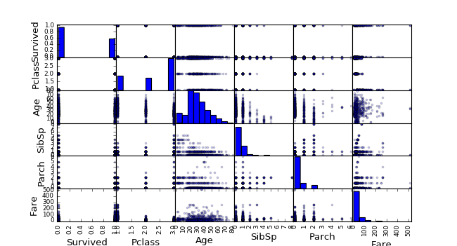

[output not shown]

```python
pd.tools.plotting.scatter_matrix(da, alpha = 0.2, hist_kwds = {"bins": 10})
```

## Review (3.2): Bivariate Association: Num-Cat

```python
da.groupby(["Survived"]).describe()
```

| Survived |  | Age | Fare | Parch | Pclass | SibSp |
| --- | --- | --- | --- | --- | --- | --- |
| 0 | count | 424.000 | 549.000 | 549.00 | 549.000 | 549.000 |
|  | mean | 30.626 | 22.118 | 0.33 | 2.532 | 0.554 |
| ... | ... | ... | ... | ... | ... | ... |
| 1 | 75% | 36.000 | 57.000 | 1.00 | 3.000 | 1.000 |
|  | max | 80.000 | 512.329 | 5.00 | 3.000 | 4.000 |

16 rows × 5 columns

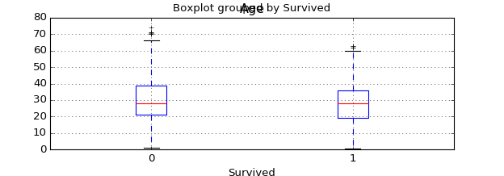

```python
da.boxplot(column = "Age", by = "Survived")
```

## Review (3.3): Bivariate Association: Cat-Cat

```python
s = da.groupby(["Survived", "Sex"])["Survived"].count()
s
```

```
Survived  Sex
0         female     81
          male      468
1         female    233
          male      109
Name: Survived, dtype: int64
```

```python
# S.unstack/DT.stack: convert index between rows and columns
s.unstack("Sex")
```

| Sex Survived | female | male |
| --- | --- | --- |
| 0 | 81 | 468 |
| 1 | 233 | 109 |

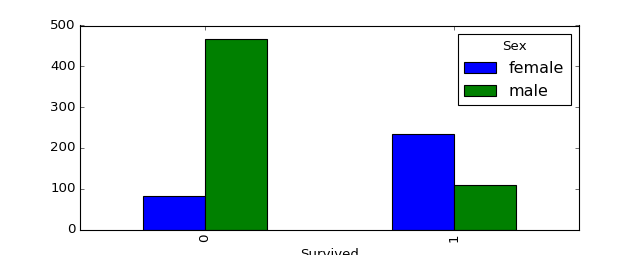

```python
s.unstack("Sex").plot(kind = "bar")
```

## Review (4.1): Data Cleaning

- An ideal dataset for machine learning: all $X$ variables are numeric, complete and well distributed
- But in reality:
  - Category variables: X = (a, b, c, d)
  - Missing values: X = (1, NA, 3, NA)
  - Biased distribution: X = (1, 2, 3, 10000)
  - Identical (sparse) distribution: X = (2, 2, 2, 2)
  - Collinearity: X1 = (1, 2, 3, 4), X2 = (2, 4, 6, 8)
- We need a general procedure to deal with these problems in data

```python
# Separate X and Y
Y, X = da['Survived'], da.drop('Survived', axis = 1)
Y.shape, X.shape
```

```
((891,), (891, 10))
```

```python
# Separate numeric and categorical part of X
X_num = X.select_dtypes(["number"])
X_cat = X.select_dtypes(["object"])
X_num.shape, X_cat.shape
```

```
((891, 5), (891, 5))
```

## Review (4.2): Data Cleaning for Categorical

```python
# In case of creating too many dummy categories, deal with sparsity first
def sparse_cat(s, sp = 0.01):
    sfreq = pd.value_counts(s) > sp*s.shape[0]
    op = s.where(s.isin(sfreq.index[sfreq]), "others")
    return(op)
X_cat1 = X_cat.apply(sparse_cat)
X_cat1.head(2)
```

| PassengerId | Name | Sex | Ticket | Cabin | Embarked |
| --- | --- | --- | --- | --- | --- |
| 1 | others | male | others | others | S |
| 2 | others | female | others | others | C |

```python
X_cat2 = pd.get_dummies(X_cat1)
X_cat2.head(2)
```

| PassengerId | Name_others | Sex_female | Sex_male | Ticket_others | Cabin_others | Embarked_C | Embarked_Q | Embarked_S | Embarked_others |
| --- | --- | --- | --- | --- | --- | --- | --- | --- | --- |
| 1 | 1 | 0 | 1 | 1 | 1 | 0 | 0 | 1 | 0 |
| 2 | 1 | 1 | 0 | 1 | 1 | 1 | 0 | 0 | 0 |

## Review (4.3): Data Cleaning for Numeric

```python
# Scale all numeric variable to mean 0 and std 1, fill missing value with mean 0
X_num1 = ((X_num - X_num.mean())/X_num.std()).fillna(0)
print(X_num1.head(2))
```

```
             Pclass    Age  SibSp  Parch   Fare
PassengerId
1             0.827 -0.530  0.433 -0.473 -0.502
2            -1.565  0.571  0.433 -0.473  0.786
```

```python
# Concat numeric and transformed categorical variables together
X1 = pd.concat([X_num1, X_cat2], axis = 1)
X1.shape
```

```
(891, 14)
```

```python
# Check and delete sparse variables which have over 99% identical or NA values
sparse = lambda x: 1-(pd.value_counts(x).iloc[0] + x.isnull().sum())/x.shape[0]
sp = X1.apply(sparse)
sp
```

```
Pclass             0.449
Age                0.801
                   ...
Embarked_S         0.277
Embarked_others    0.002
dtype: float64
```

```python
X2 = X1.loc[:, sp > 0.01]
X2.shape
```

```
(891, 10)
```

## Review (4.4): Data Cleaning for Collinearity

```python
# Find collinearity based on lower half correlation matrix
abscor = np.abs(np.tril(np.corrcoef(X2, rowvar = 0), -1))
abscor
```

```
array([[ 0.   ,  0.   ,  0.   ,  0.   ,  0.   ,  0.   ,  0.   ,  0.   ,
         0.   ,  0.   ],
       [ 0.331,  0.   ,  0.   ,  0.   ,  0.   ,  0.   ,  0.   ,  0.   ,
         0.   ,  0.   ],
       [ 0.083,  0.233,  0.   ,  0.   ,  0.   ,  0.   ,  0.   ,  0.   ,
         0.   ,  0.   ],
       [ 0.018,  0.179,  0.415,  0.   ,  0.   ,  0.   ,  0.   ,  0.   ,
         0.   ,  0.   ],
       [ 0.549,  0.092,  0.16 ,  0.216,  0.   ,  0.   ,  0.   ,  0.   ,
         0.   ,  0.   ],
       [ 0.132,  0.084,  0.115,  0.245,  0.182,  0.   ,  0.   ,  0.   ,
         0.   ,  0.   ],
       [ 0.132,  0.084,  0.115,  0.245,  0.182,  1.   ,  0.   ,  0.   ,
         0.   ,  0.   ],
       [ 0.243,  0.032,  0.06 ,  0.011,  0.269,  0.083,  0.083,  0.   ,
         0.   ,  0.   ],
       [ 0.221,  0.014,  0.026,  0.081,  0.117,  0.074,  0.074,  0.148,
         0.   ,  0.   ],
       [ 0.082,  0.027,  0.071,  0.063,  0.167,  0.126,  0.126,  0.778,
         0.497,  0.   ]])
```

```python
# Delete variables with any |correlation| > 0.9)
X3 = X2.loc[:, np.all(abscor < 0.9, axis = 1)]
X3.shape
```

```
(891, 9)
```

## Review (4.5): Integrated Data Cleaning

```python
def CleanData(da, sp = 0.01, cor = 0.9, fnorm = lambda x: ((x - x.mean())/x.std()).fillna(0)):
    X_num = da.select_dtypes(["number"])
    X_cat = da.select_dtypes(["object"])
    if(X_num.shape[1] > 0):
        X_num = fnorm(X_num)
    if(X_cat.shape[1] > 0):
        X_cat = pd.get_dummies(X_cat.apply(sparse_cat, sp = sp))
    X = pd.concat([X_num, X_cat], axis = 1)
    if(sp > 0):
        X = X.loc[:, X.apply(sparse) > sp]
    if(cor < 1):
        abscor = np.abs(np.tril(np.corrcoef(X, rowvar = 0), -1))
        X = X.loc[:, np.all(abscor < cor, axis = 1)]
    return(X)
```

```python
X = CleanData(da.drop("Survived", axis = 1))
X
```

| PassengerId | Pclass | Age | SibSp | Parch | Fare | Sex_female | Embarked_C | Embarked_Q | Embarked_S |
| --- | --- | --- | --- | --- | --- | --- | --- | --- | --- |
| 1 | 0.827 | -0.530 | 0.433 | -0.473 | -0.502 | 0 | 0 | 0 | 1 |
| 2 | -1.565 | 0.571 | 0.433 | -0.473 | 0.786 | 1 | 1 | 0 | 0 |
| ... | ... | ... | ... | ... | ... | ... | ... | ... | ... |
| 890 | -1.565 | -0.255 | -0.474 | -0.473 | -0.044 | 0 | 1 | 0 | 0 |
| 891 | 0.827 | 0.158 | -0.474 | -0.473 | -0.492 | 0 | 0 | 1 | 0 |

891 rows × 9 columns

## Review (5.1): Machine Learning: Classification

- Given data $(X, Y)$ with binary outcome $y_i = 0,1$ for $i = 1,\cdots,n$
- Distance between continuous $\hat{Y} = E(Y) = f(X,\theta)$ and binary $Y$:
  - Continuous Measurement:
    - Log loss ($-\log(f(Y|\hat{Y})$): $L(Y, \hat{Y}) = -\sum_{i=1}^n\left(y_i\log(\hat{y}_i)+(1-y_i)\log(1-\hat{y}_i)\right)$
  - Binarize $\hat{Y}$ based on a threshold $\hat{Y}^{(c)} = 1(\hat{Y} > c)$
    - Misclassification error: $L(Y, \hat{Y}) = \sum_{i=1}^n1(y_i \neq \hat{y}_i^{(c)})$
    - 4 kinds of classification outcome: True Positive, True Negative, False Positive, False Negative

```python
import sklearn.metrics as met
y = np.array([0, 0, 0, 0, 1, 1, 1, 1, 1, 1])
yhat = np.array([0.1, 0.3, 0.4, 0.6, 0.2, 0.5, 0.7, 0.8, 0.9, 1])
pd.DataFrame(met.confusion_matrix(y, yhat > 0.5), index = ["y0", "y1"], columns = ["yhat0", "yhat1"])
```

|  | yhat0 | yhat1 |
| --- | --- | --- |
| y0 | 3 | 1 |
| y1 | 2 | 4 |

## Review (5.2): Machine Learning: ROC and AUC

- True Positive Rate (Sensitivity): $TPR^{(c)} = 1-FNR^{(c)} = \frac{\sum_{i=1}^n1(\hat{y}_i^{(c)} = y_i = 1)}{\sum_{i=1}^n1(y_i = 1)}$
- True Negative Rate (Specificity): $TNR^{(c)} = 1-FPR^{(c)} = \frac{\sum_{i=1}^n1(\hat{y}_i^{(c)} = y_i = 0)}{\sum_{i=1}^n1(y_i = 0)}$
- Receiver operating characteristic (ROC): curve of $(1 - TNR^{(c)}, TPR^{(c)})$
- Area Under Curve (AUC): between 0 (totally false) and 1 (totally true), usually greater than 0.5 (totally random)

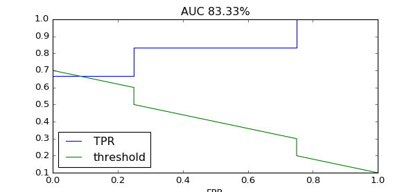

```python
def ROC(Y, Yhat):
    roc = met.roc_curve(Y, Yhat)
    pd.DataFrame({"FPR": roc[0], "TPR": roc[1], "threshold": roc[2]}).set_index(
        "FPR").plot(title = "AUC {:.2%}".format(met.auc(roc[0], roc[1])))
ROC(y, yhat)
```

## Review (5.3): CV Model Functions

- Use defined machine learning functions last class, revising for classification

```python
def Kfolds(x, k = 5, seed = 1):
    np.random.seed(seed)
    op = np.array_split(np.random.permutation(x), k)
    return(op)
ir_cv = Kfolds(Y.index)
[i.shape for i in ir_cv]
```

```
[(179,), (178,), (178,), (178,), (178,)]
```

```python
def cv_train_class(X, Y, ir_cv, fmodel, fscore = met.roc_auc_score, **kwargs):
    modelL, losstL, lossvL = [], [], []
    for ir_v in ir_cv:
        ir_t = np.setdiff1d(np.hstack(ir_cv), ir_v)
        Xt, Xv, Yt, Yv = X.loc[ir_t], X.loc[ir_v], Y.loc[ir_t], Y.loc[ir_v]
        # Train a scikit-learn model
        model = fmodel(**kwargs)
        model.fit(Xt, Yt)
        # predict and get training-validation loss
        Ythat = model.predict_proba(Xt)[:,1]
        losst = fscore(Yt.values, Ythat)
        Yvhat = model.predict_proba(Xv)[:,1]
        lossv = fscore(Yv.values, Yvhat)
        # save model and training-validation loss
        modelL.append(model)
        losstL.append(losst)
        lossvL.append(lossv)
    op = {"modelL": modelL,
          "loss": pd.DataFrame({"loss_train": losstL, "loss_val": lossvL})}
    return(op)
```

## Review (5.4): Logistic Regression

- GLM: $\hat{Y} = g^{-1}(X\beta)$ with link function $g(\cdot)$
- Logistic Regression: link binary $Y$ and linear $X\beta$ using logit function $g^{-1}(X\beta) = \frac{1}{1+\exp(-X\beta)}$
- Maximum likelihood estimator $\hat{\beta}$: minimize log loss $L(Y, \hat{Y}) = -\sum_{i=1}^n\left(y_i\log(\hat{y}_i)+(1-y_i)\log(1-\hat{y}_i)\right)$
- Regularization with penalty: $\hat{\beta} = \arg\min_{\beta}\left(L(Y, \hat{Y}) + \lambda P(\beta)\right)$
  - Ridge (L2 dist): $P(\beta) = \sum_{i=1}^p\beta_i^2$
  - Lasso (L1 dist): $P(\beta) = \sum_{i=1}^p|\beta_i|$

```python
# Default in scikit-learn, logistic regression use L2 penalty and inverse penalty coefficient C (= 1/lambda) = 1
import sklearn.linear_model as lm
md_lg = cv_train_class(X, Y, ir_cv, lm.LogisticRegression)
md_lg["loss"].mean()
```

```
loss_train    0.858
loss_val      0.855
dtype: float64
```

```python
# With L1 penalty function and inverse penalty coefficient C = 10
md_lgl1 = cv_train_class(X, Y, ir_cv, lm.LogisticRegression, penalty='l1', C = 10)
md_lgl1["loss"].mean()
```

```
loss_train    0.858
loss_val      0.856
dtype: float64
```

## Review (5.5): Prediction and ROC Curve

```python
# model.predict(X): Binarized prediction outcome
md_lg["modelL"][0].predict(X.loc[ir_cv[0]])
```

```
array([1, 0, 1, ..., 0, 0, 1])
```

```python
# model.predict_proba(X): Probability prediction of column [Class 0, Class 1]
yvhat0 = md_lg["modelL"][0].predict_proba(X.loc[ir_cv[0]])[:,1]
yvhat0
```

```
array([ 0.864,  0.084,  0.868, ...,  0.135,  0.181,  0.722])
```

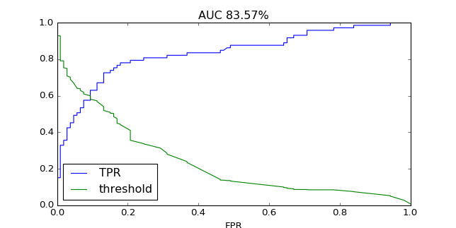

```python
ROC(Y.loc[ir_cv[0]], yvhat0)
```

## Review (5.6): Tree-based Methods

```python
import sklearn.tree as tree
md_tree = cv_train_class(X, Y, ir_cv, tree.DecisionTreeClassifier, max_depth = 3)
md_tree["loss"].mean()
```

```
loss_train    0.867
loss_val      0.851
dtype: float64
```

```python
import sklearn.ensemble as ensm
md_rf = cv_train_class(X, Y, ir_cv, ensm.RandomForestClassifier, n_estimators = 20, max_depth = 5)
md_rf["loss"].mean()
```

```
loss_train    0.913
loss_val      0.868
dtype: float64
```

```python
md_gbt = cv_train_class(X, Y, ir_cv, ensm.GradientBoostingClassifier, n_estimators = 20, learning_rate = 0.1)
md_gbt["loss"].mean()
```

```
loss_train    0.901
loss_val      0.867
dtype: float64
```

## Review (5.7): Variable Selection in Tree-based Models

```python
wL = pd.concat([pd.Series(model.feature_importances_, index = X.columns)
                  for model in md_rf["modelL"]], axis = 1)
wL
```

|  | 0 | 1 | 2 | 3 | 4 |
| --- | --- | --- | --- | --- | --- |
| Pclass | 0.151 | 0.131 | 0.155 | 0.146 | 0.127 |
| Age | 0.115 | 0.100 | 0.102 | 0.119 | 0.088 |
| ... | ... | ... | ... | ... | ... |
| Embarked_Q | 0.011 | 0.013 | 0.004 | 0.001 | 0.010 |
| Embarked_S | 0.029 | 0.021 | 0.014 | 0.018 | 0.026 |

9 rows × 5 columns

```python
(wL/wL.mean()).T.describe().T.sort_values("mean", ascending = False)
```

|  | count | mean | std | min | 25% | 50% | 75% | max |
| --- | --- | --- | --- | --- | --- | --- | --- | --- |
| Sex_female | 5.0 | 4.181 | 0.170 | 3.989 | 4.062 | 4.202 | 4.220 | 4.431 |
| Fare | 5.0 | 1.490 | 0.181 | 1.335 | 1.359 | 1.441 | 1.534 | 1.783 |
| ... | ... | ... | ... | ... | ... | ... | ... | ... |
| Embarked_C | 5.0 | 0.107 | 0.010 | 0.100 | 0.101 | 0.105 | 0.107 | 0.123 |
| Embarked_Q | 5.0 | 0.072 | 0.044 | 0.012 | 0.039 | 0.091 | 0.098 | 0.118 |

9 rows × 8 columns

## Final Project

- Register, download datasets and raise a prediction result on [Kaggle Titanic](https://www.kaggle.com/c/titanic)
- Try to improve your result by improving your data cleaning and machine learning procedures
  - String operations in variables
  - Variable Selection
  - More models ([XGBoost](https://github.com/dmlc/xgboost), Neural Network ([Keras](https://github.com/fchollet/keras)), etc)
  - Hyperparameter optimization in models
  - Be careful about over-fitting
- Wait for your final score after Dec 31

```python
'''
The Word of God Stands Forever


    A voice says, “Cry!”

        And I said, “What shall I cry?”

    All flesh is grass,

        and all its beauty is like the flower of the field.

    The grass withers, the flower fades

        when the breath of the LORD blows on it;

        surely the people are grass.

    The grass withers, the flower fades,

        but the word of our God will stand forever.



(Isaiah 40:6-8 ESV)
'''
```